# Kennedy et al. (2014) Replication Study, by Lindsey Sample

We subtracted the Lag 8 from the Lag 2 of each condition in order to isolate the effect of seeing the target image (no target image is shown 200ms after the distractor in the Lag 8 condition). We used the same electordes mentioned in the N2 distractor analysis for the N2 component.

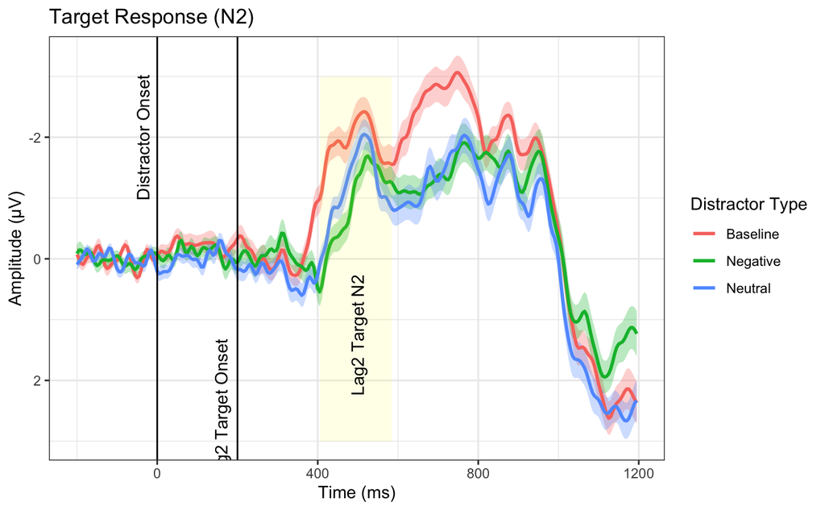

#####N2 Target 2-Factor ANOVA

Two factor ANOVA (hemisphere: left, right x distractor type: neg, neutral, baseline), mean negativity of N2 of lag 2 elicited by target pictures

|  | Effect | DFn | DFd | F | p | p<.05 | ges |
| --- | --- | --- | --- | --- | --- | --- | --- |
| 2 | hemisphere | 1 | 21 | 0.02319651 | 0.880400976 |  | 5.924205e-05 |
| 3 | distractor.condition | 2 | 42 | 6.62055733 | 0.003167554 | * | 9.767684e-02 |
| 4 | hemisphere:distractor.condition | 2 | 42 | 0.07772913 | 0.925347783 |  | 5.218901e-04 |

```
$`Mauchly's Test for Sphericity`
```

|  | Effect | W | p | p<.05 |
| --- | --- | --- | --- | --- |
| 3 | distractor.condition | 0.5822247 | 0.004476168 | * |
| 4 | hemisphere:distractor.condition | 0.6252977 | 0.009138363 | * |

```
$`Sphericity Corrections`
```

|  | Effect | GGe | p[GG] | p[GG]<.05 | HFe | p[HF] | p[HF]<.05 |
| --- | --- | --- | --- | --- | --- | --- | --- |
| 3 | distractor.condition | 0.7053304 | 0.008707451 | * | 0.7410801 | 0.00769685 | * |
| 4 | hemisphere:distractor.condition | 0.7274302 | 0.868816612 |  | 0.7676315 | 0.87954194 |  |

```
NA
```

#####N2 Target t-tests

Paired sample t-test comparing baseline and negative conditions for the N2 component response to the target image.

```r
#baseline v. negative
t.test(M ~ distractor.condition,
       data = (n2.target.t.test.data %>% filter(distractor.condition != "Neutral")),
       paired = TRUE,
       alternative="less")
```

```
    Paired t-test

data:  M by distractor.condition
t = -3.5947, df = 21, p-value = 0.0008525
alternative hypothesis: true difference in means is less than 0
95 percent confidence interval:
      -Inf -0.516237
sample estimates:
mean of the differences
             -0.9902751
```

Paired sample t-test comparing baseline and neutral conditions for the N2 component response to the target image.

```r
#baseline v. neutral
t.test(M ~ distractor.condition,
       data = (n2.target.t.test.data %>% filter(distractor.condition != "Negative")),
       paired = TRUE,
       alternative="less")
```

```
    Paired t-test

data:  M by distractor.condition
t = -3.7654, df = 21, p-value = 0.0005685
alternative hypothesis: true difference in means is less than 0
95 percent confidence interval:
      -Inf -0.390986
sample estimates:
mean of the differences
             -0.7200393
```

Paired sample t-test comparing neutral and negative conditions for the N2 component response to the target image.

```r
#negative v. neutral
t.test(M ~ distractor.condition,
       data = (n2.target.t.test.data %>% filter(distractor.condition != "Baseline")),
       paired = TRUE,
       alternative="greater")
```

```
    Paired t-test

data:  M by distractor.condition
t = 0.76434, df = 21, p-value = 0.2266
alternative hypothesis: true difference in means is greater than 0
95 percent confidence interval:
 -0.3381435        Inf
sample estimates:
mean of the differences
              0.2702359
```

###P3b Component

####Target P3b This analysis attempts to point to consolidation into working memory of the target image, where we would expect a smaller peak in the negative condition, followed by the neutral condition (compared to the baseline condition). Our time window was 635-995ms after distractor onset.

We ran a one-factor ANOVA to compare voltage across distractor conditions for the event of a target image within the P3b component. We report a significan effect of distractor conditon, F(2,42)= 4.80, p=.013.

We ran post-hoc paired, one-tailed t-tests to further analyze the relationship between conditions. We found a significant difference between the baseline and neutral conditions in that baseline P3b amplitude exceeded neutral P3b amplitude, t(21)= 2.57, p=.008. We then analyzed whether the baseline condition exceeded the negative conditon and found a significant effect here as well, t(21)= 2.57, p=.008. We then tested whether or not the neutral conditon exceeded the negative conditon in P3b targer effect and found no significant difference here, t(21)= .81, p=.78.

#####Target P3b Visualization In this visualization we subtracted Lag 8 from each of the Lag 2 conditions to isolate the target image. We examined electrodes 54, 55, 79, 78, 61 and 62 for the P3b component.

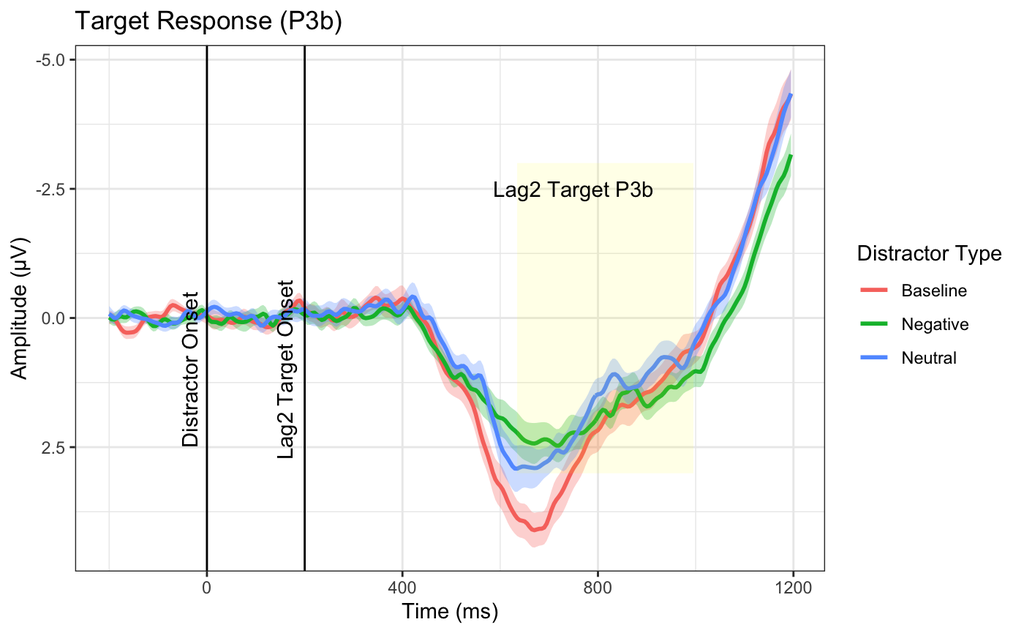

#####Target P3b ANOVA A one-way repeated measures ANOVA (distractor type: negative, neutral, baseline: lag 2) on the average amplitude between 435 to 795 ms after the target onset at lag 2 will be conducted to determine the main effect of distractor types on the target in the P3b component.

|  | Effect | DFn | DFd | F | p | p<.05 | ges |
| --- | --- | --- | --- | --- | --- | --- | --- |
| 2 | distractor.condition | 2 | 42 | 4.80854 | 0.01316961 | * | 0.0329214 |

```
$`Mauchly's Test for Sphericity`
```

|  | Effect | W | p | p<.05 |
| --- | --- | --- | --- | --- |
| 2 | distractor.condition | 0.8682762 | 0.2435449 |  |

```
$`Sphericity Corrections`
```

|  | Effect | GGe | p[GG] | p[GG]<.05 | HFe | p[HF] | p[HF]<.05 |
| --- | --- | --- | --- | --- | --- | --- | --- |
| 2 | distractor.condition | 0.8836078 | 0.01701265 | * | 0.9587469 | 0.01441872 | * |

```
NA
```

#####Target P3b t-tests One tailed, paired t-test comparing baseline > neutral conditions for the P3b component response to the target image.

```
    Paired t-test

data:  m.volt by distractor.condition
t = 2.5738, df = 21, p-value = 0.008851
alternative hypothesis: true difference in means is greater than 0
95 percent confidence interval:
 0.1896923       Inf
sample estimates:
mean of the differences
              0.5723399
```

One tailed, paired t-test comparing baseline > negative conditions for the P3b component response to the target image.

```r
#baseline > negative?
t.test(m.volt ~ distractor.condition,
       data = (targetP3b.anova %>% filter(distractor.condition != "Neutral")),
       paired = TRUE,
       alternative="greater")
```

```
    Paired t-test

data:  m.volt by distractor.condition
t = 2.5764, df = 21, p-value = 0.008801
alternative hypothesis: true difference in means is greater than 0
95 percent confidence interval:
 0.1406848       Inf
sample estimates:
mean of the differences
              0.4236161
```

One tailed, paired t-test comparing neutral > negative conditions for the P3b component response to the target image.

```r
#neutral > negative?
t.test(m.volt ~ distractor.condition,
       data = (targetP3b.anova %>% filter(distractor.condition != "Baseline")),
       paired = TRUE,
       alternative="less")
```

```
    Paired t-test

data:  m.volt by distractor.condition
t = 0.81187, df = 21, p-value = 0.787
alternative hypothesis: true difference in means is less than 0
95 percent confidence interval:
      -Inf 0.4639393
sample estimates:
mean of the differences
              0.1487238
```

####Distractor P3b